# Association tests

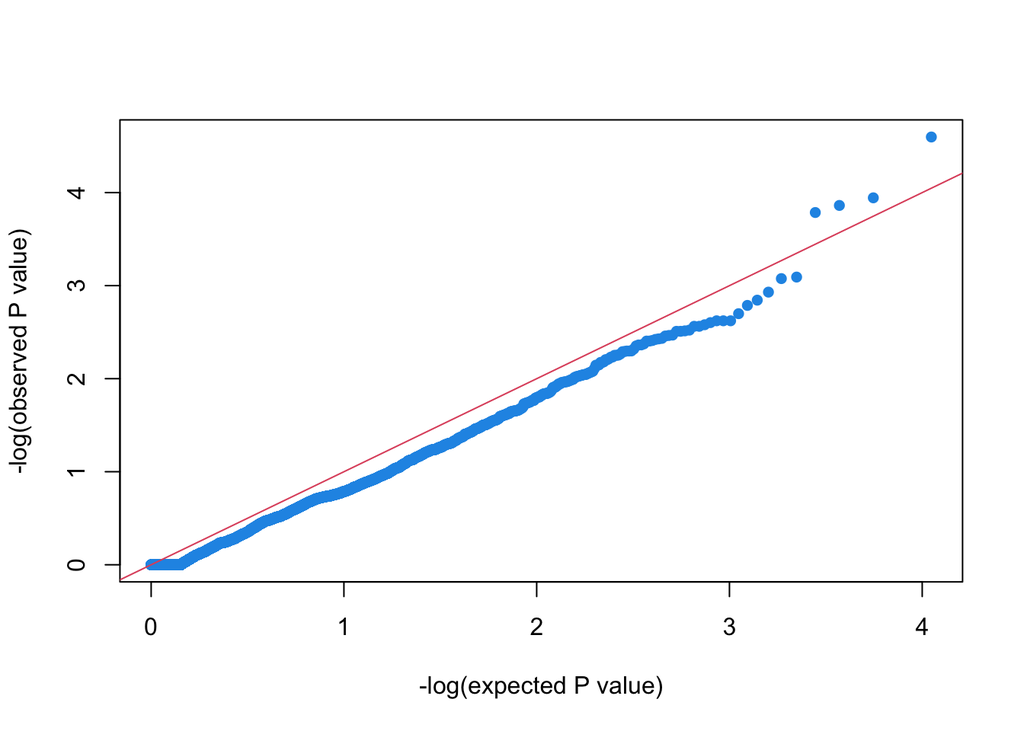

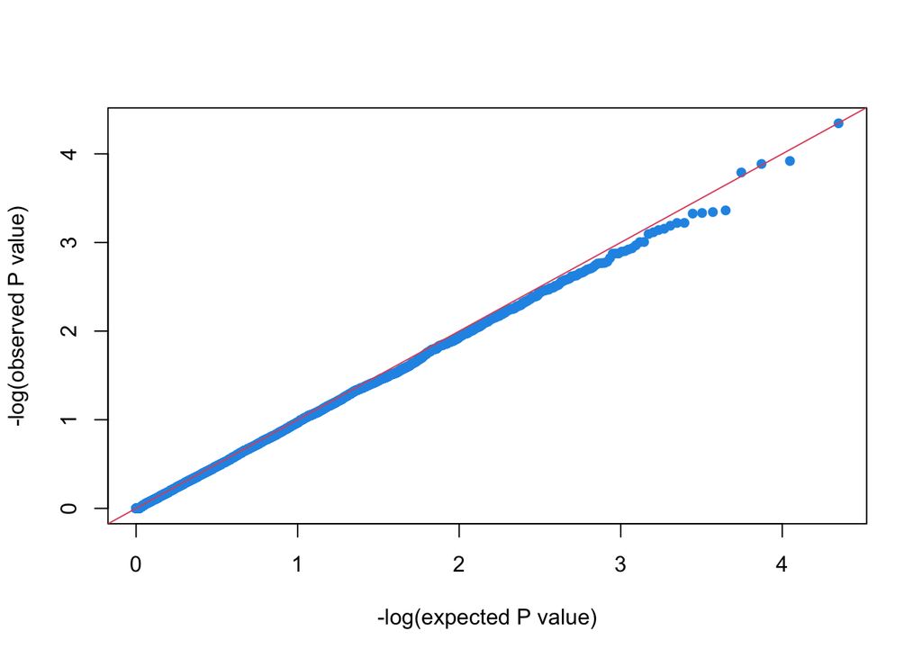

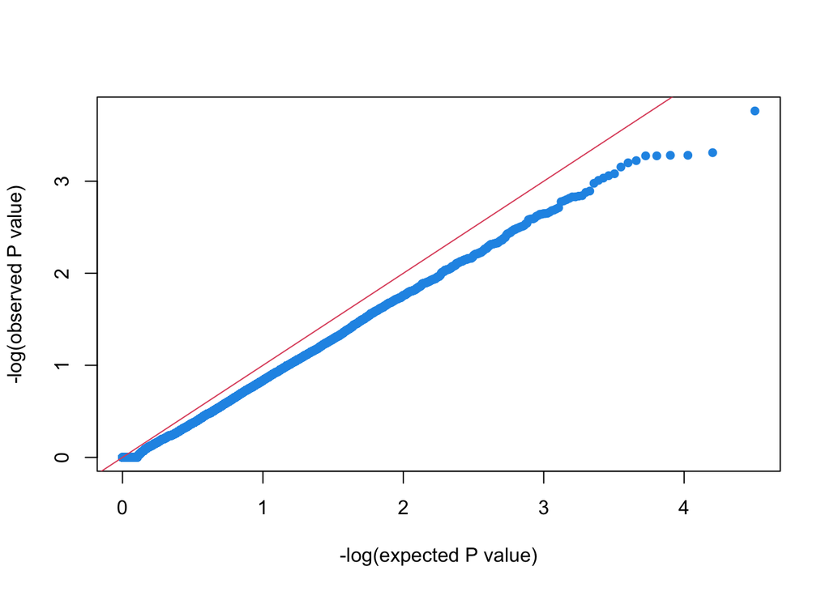

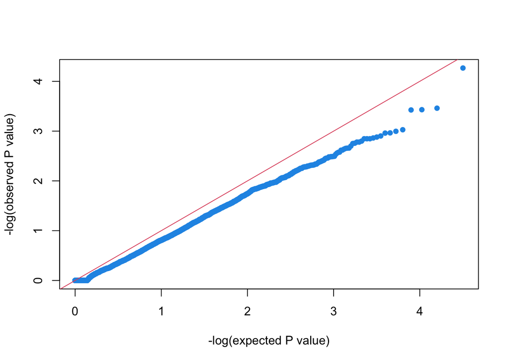

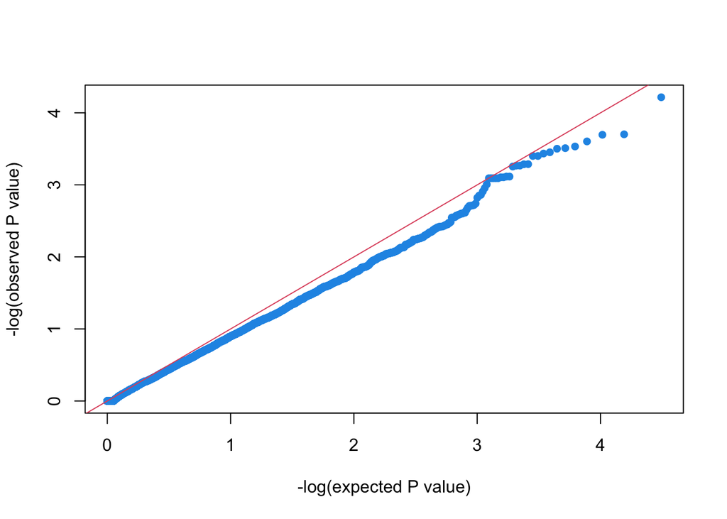

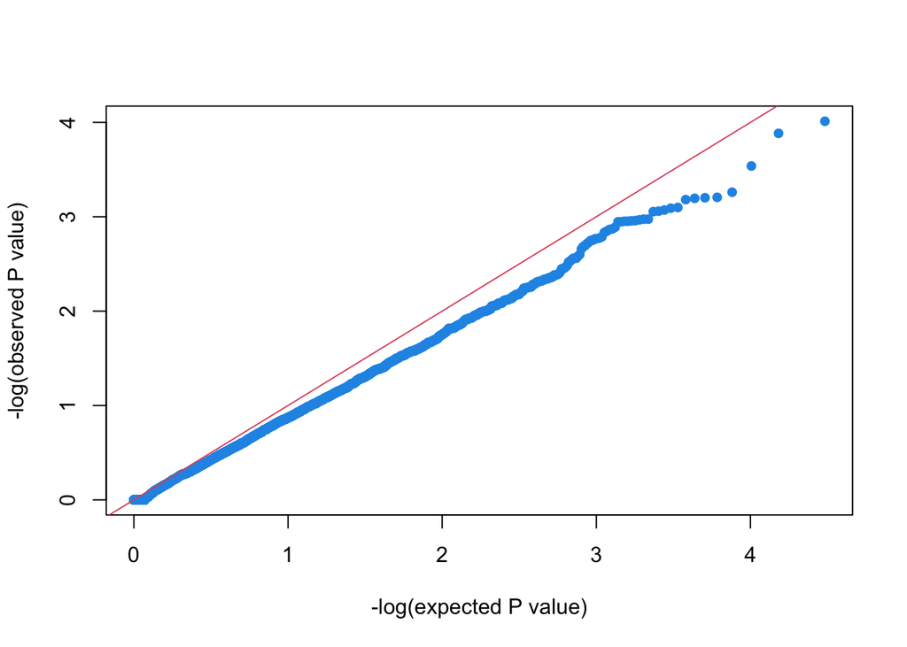

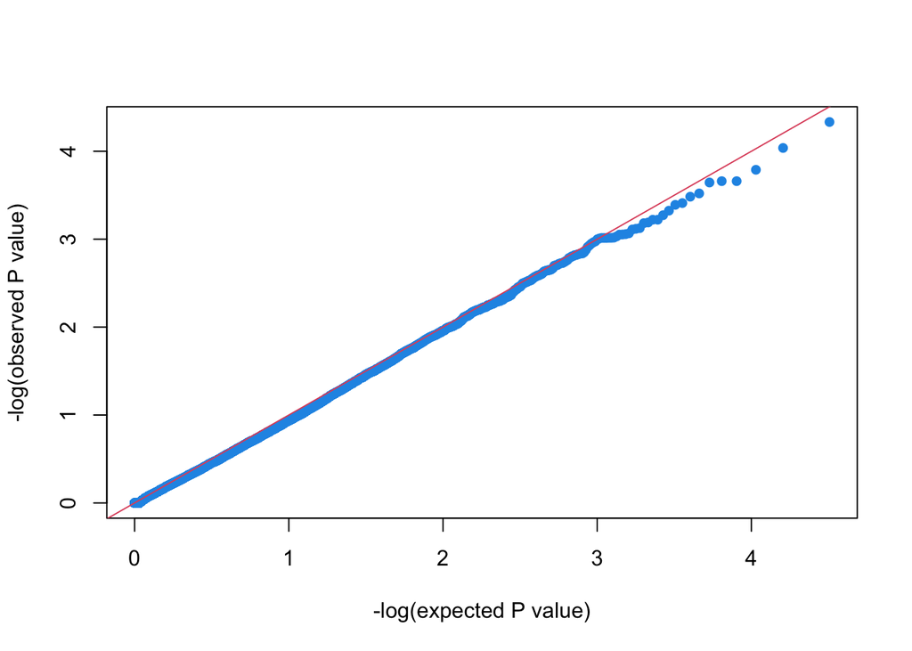

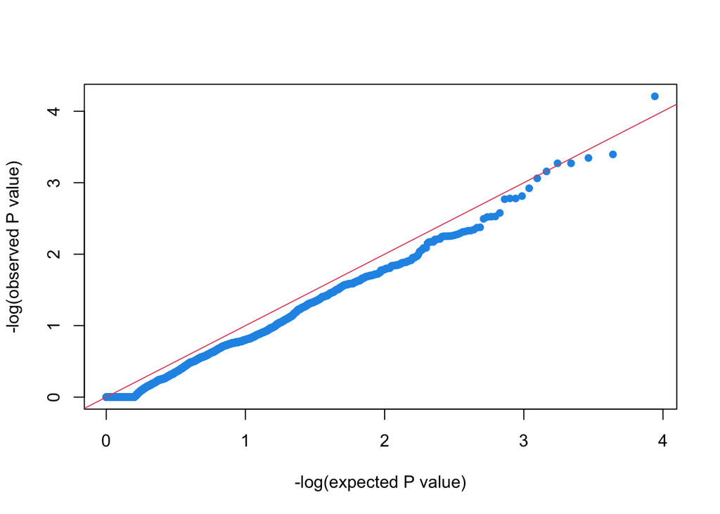

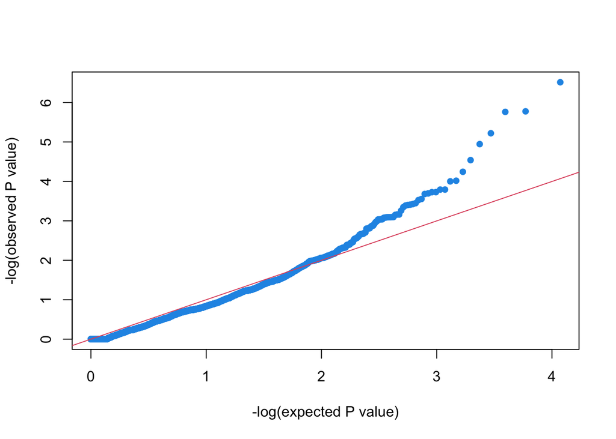

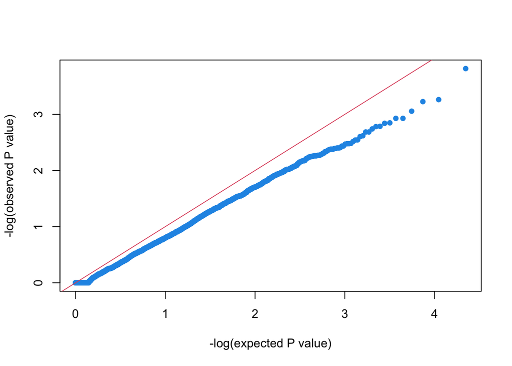

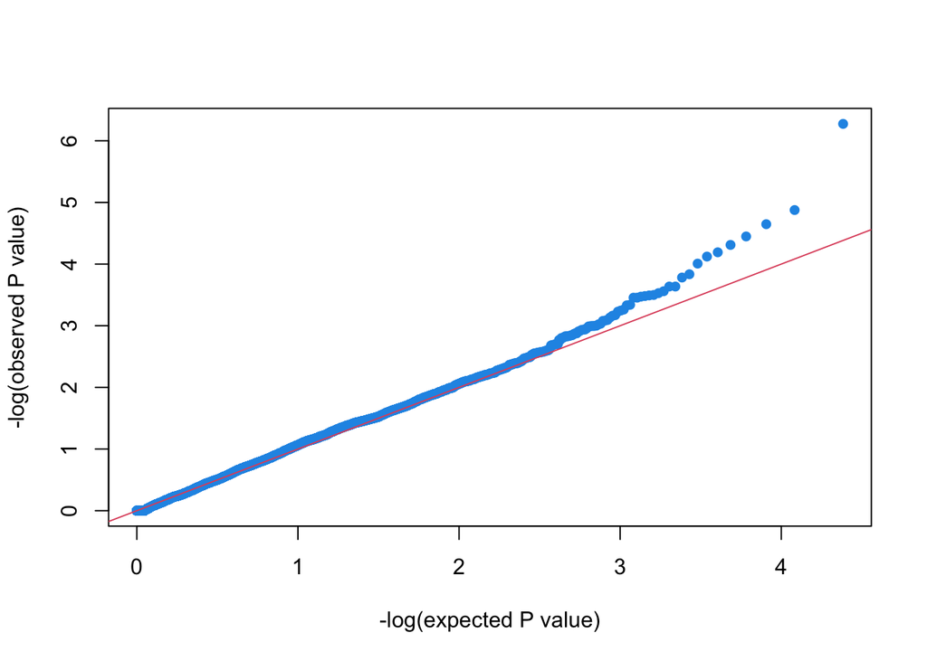

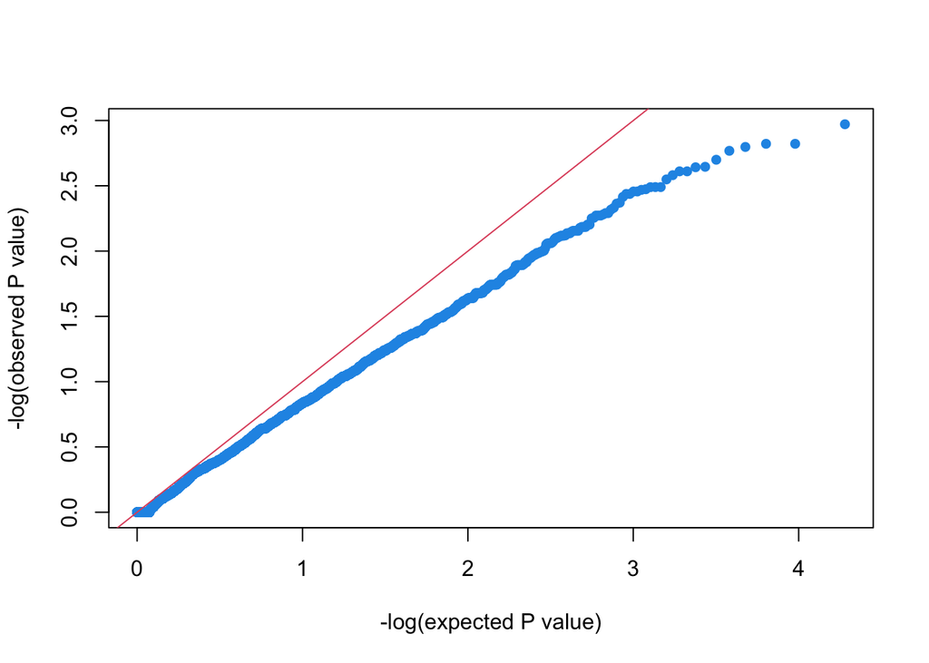

[3 more figures not shown]

```r
lapply(my.gwas, function(x){
  qqpval(x %>% pull(codominant))
})
```

These qqplot plots sorted observed Pvalues on the y axis and expected Pvalues based on aw uniform distribution. If you look at the underlying function these are produced with `(1:n)/(n+1)` where `n` is the number of loci tested.

Let's plot the qqplot with Confidence intervals as well. To do so I use the gg_qqplot function from [this blog](https://slowkow.com/notes/ggplot2-qqplot/). First I define the function.

```r
gg_qqplot <- function(ps, ci = 0.95) {
  n  <- length(ps)
  df <- data.frame(
    observed = -log10(sort(ps)),
    expected = -log10(ppoints(n)),
    clower   = -log10(qbeta(p = (1 - ci) / 2, shape1 = 1:n, shape2 = n:1)),
    cupper   = -log10(qbeta(p = (1 + ci) / 2, shape1 = 1:n, shape2 = n:1))
  )
  log10Pe <- expression(paste("Expected -log"[10], plain((p-value))))
  log10Po <- expression(paste("Observed -log"[10], plain((p-value))))
  ggplot(df) +
    geom_ribbon(
      mapping = aes(x = expected, ymin = clower, ymax = cupper),
      alpha = 0.1
    ) +
    geom_point(aes(expected, observed), shape = 1, size = 2) +
    geom_abline(intercept = 0, slope = 1, alpha = 0.5) +
    # geom_line(aes(expected, cupper), linetype = 2, size = 0.5) +
    # geom_line(aes(expected, clower), linetype = 2, size = 0.5) +
    xlab(log10Pe) +
    ylab(log10Po)
}
```

Then I use it to produce the qqplot.

```r
#plot
my.plots <- lapply(my.gwas, function(x){
  y <- gg_qqplot(x %>%
                  pull(codominant),
                ci = 0.95) +
  theme_bw(base_size = 12) +
  theme(
    axis.ticks = element_line(size=0.5),
    panel.grid = element_blank()
  )

  return(y)
})
```

Plot all plots together

```r
library(gridExtra)
```

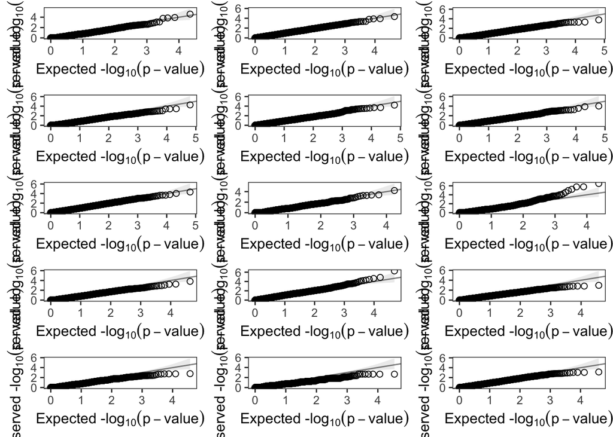

```r
grid.arrange(grobs=my.plots,ncol=3)
```

Save the resulting graph

```r
ggsave(file = "../7_GWAS/7_4_qplots.png",
       arrangeGrob(grobs = my.plots, ncol = 3), height = 10, width = 10)
```

This shows us that the lower p-values we obtained are outside the expected 95% Confidence Intervals. Let's see how many markers are significant at an alpha value of 0.05 and after FDR correction.

#### 6.2. Assess significance

```r
lapply(my.gwas, function(x){
  nrow(x %>% filter(codominant < 0.05))
})
```

```
## $P1
## [1] 321
##
## $P10
## [1] 1035
##
## $P11
## [1] 976
##
## $P12
## [1] 951
##
## $P13
## [1] 1075
##
## $P14
## [1] 977
##
## $P15
## [1] 1421
##
## $P2
## [1] 310
##
## $P3
## [1] 430
##
## $P4
## [1] 646
##
## $P5
## [1] 1425
##
## $P6
## [1] 504
##
## $P7
## [1] 503
##
## $P8
## [1] 249
##
## $P9
## [1] 714
```

```r
lapply(my.gwas, function(x){
  x %>% filter(codominant < 0.0001) %>% select(-comments)
})
```

```
## $P1
## # A tibble: 1 × 3
##   MarkerID             codominant Pop
##   <chr>                     <dbl> <chr>
## 1 scaffold_5_168028198  0.0000253 P1
##
## $P10
## # A tibble: 1 × 3
##   MarkerID             codominant Pop
##   <chr>                     <dbl> <chr>
## 1 scaffold_5_176969269  0.0000452 P10
##
## $P11
## # A tibble: 0 × 3
## # ℹ 3 variables: MarkerID <chr>, codominant <dbl>, Pop <chr>
##
## $P12
## # A tibble: 1 × 3
##   MarkerID             codominant Pop
##   <chr>                     <dbl> <chr>
## 1 scaffold_3_123000171  0.0000541 P12
##
## $P13
## # A tibble: 1 × 3
##   MarkerID             codominant Pop
##   <chr>                     <dbl> <chr>
## 1 scaffold_12_58618979  0.0000609 P13
##
## $P14
## # A tibble: 1 × 3
##   MarkerID           codominant Pop
##   <chr>                   <dbl> <chr>
## 1 scaffold_1_5316761  0.0000973 P14
##
## $P15
## # A tibble: 2 × 3
##   MarkerID            codominant Pop
##   <chr>                    <dbl> <chr>
## 1 scaffold_1_40321756  0.0000918 P15
## 2 scaffold_8_93583839  0.0000465 P15
```

[output cut: 38 more lines]

```
## $P6
## # A tibble: 0 × 3
## # ℹ 3 variables: MarkerID <chr>, codominant <dbl>, Pop <chr>
##
## $P7
## # A tibble: 0 × 3
## # ℹ 3 variables: MarkerID <chr>, codominant <dbl>, Pop <chr>
##
## $P8
## # A tibble: 0 × 3
## # ℹ 3 variables: MarkerID <chr>, codominant <dbl>, Pop <chr>
##
## $P9
## # A tibble: 0 × 3
## # ℹ 3 variables: MarkerID <chr>, codominant <dbl>, Pop <chr>
```

```r
my.gwas <- lapply(my.gwas, function(x){
  holm <- p.adjust(x$codominant,
                method = "holm",
                n=length(x$codominant))

  fdr <- p.adjust(x$codominant,
                method = "fdr",
                n=length(x$codominant))

  bonferroni <- p.adjust(x$codominant,
                method = "bonferroni",
                n=length(x$codominant))

  BH <- p.adjust(x$codominant,
                method = "BH",
                n=length(x$codominant))

  BY <- p.adjust(x$codominant,
                method = "BY",
                n=length(x$codominant))

  hommel <- p.adjust(x$codominant,
                method = "hommel",
                n=length(x$codominant))

  hochberg <- p.adjust(x$codominant,
                method = "hochberg",
                n=length(x$codominant))

  z <- x %>% add_column("holm" = holm,
                        "fdr" = fdr,
                        "bonferroni" = bonferroni,
                        "BH" = BH,
                        "BY" = BY,
                        "Hommel" = hommel,
                        "Hochberg" = hochberg)

  return(z)
})
```

How many markers are significant now at an alpha value of 0.05?

```r
lapply(my.gwas, function(x){
  nrow(x %>% filter(fdr < 0.05))
})
```

```
## $P1
## [1] 0
##
## $P10
## [1] 0
##
## $P11
## [1] 0
##
## $P12
## [1] 0
##
## $P13
## [1] 0
##
## $P14
## [1] 0
##
## $P15
## [1] 0
##
## $P2
## [1] 0
##
## $P3
## [1] 5
##
## $P4
## [1] 0
##
## $P5
## [1] 1
##
## $P6
## [1] 0
##
## $P7
## [1] 0
##
## $P8
## [1] 0
##
## $P9
## [1] 0
```

Let's see which are these markers.

```r
my.gwas$P3 %>% filter(fdr <= 0.05) %>% select(-comments)
```

```
## # A tibble: 5 × 10
##   MarkerID    codominant Pop      holm     fdr bonferroni      BH     BY  Hommel
##   <chr>            <dbl> <chr>   <dbl>   <dbl>      <dbl>   <dbl>  <dbl>   <dbl>
## 1 scaffold_5…    3.07e-7 P3    0.00362 0.00362    0.00362 0.00362 0.0360 0.00362
## 2 scaffold_5…    1.13e-5 P3    0.134   0.0268     0.134   0.0268  0.266  0.134
## 3 scaffold_5…    6.02e-6 P3    0.0710  0.0178     0.0711  0.0178  0.177  0.0710
## 4 scaffold_5…    1.73e-6 P3    0.0204  0.00681    0.0204  0.00681 0.0678 0.0204
## 5 scaffold_5…    1.67e-6 P3    0.0197  0.00681    0.0197  0.00681 0.0678 0.0197
## # ℹ 1 more variable: Hochberg <dbl>
```

```r
my.gwas$P5 %>% filter(fdr <= 0.05) %>% select(-comments)
```

```
## # A tibble: 1 × 10
##   MarkerID         codominant Pop     holm    fdr bonferroni     BH    BY Hommel
##   <chr>                 <dbl> <chr>  <dbl>  <dbl>      <dbl>  <dbl> <dbl>  <dbl>
## 1 scaffold_5_1680…    5.32e-7 P5    0.0129 0.0129     0.0129 0.0129 0.137 0.0129
## # ℹ 1 more variable: Hochberg <dbl>
```

All six SNPs are on scaffold 5, from 3 different "loci" and we have two pairs that occur within 30 base pairs of each other.

Now, let's calculate the genomic inflation factor for population 3

```r
my.chisq<- qchisq(1 - my.gwas$P3$codominant, 1)
median(my.chisq) / qchisq(0.5, 1)
```

```
## [1] 0.4535186
```

```r
my.chisq<- qchisq(1 - my.gwas$P5$codominant, 1)
median(my.chisq) / qchisq(0.5, 1)
```

```
## [1] 0.9221863
```

For population 3 (LS-Pal) it is lower than 1, so no population structure. Yet it is a bit too low.

Let's finish by saving the dataset with adjusted p-values. This is table S11 in the supplementary material

```r
temp <- bind_rows(my.gwas)

write_delim(temp,file = "../7_GWAS/7_4_codominant_0.8_corrected.txt",
            delim = "\t",col_names = TRUE)
```

## 5. Compare and plot on genome

Let's start by plotting significance of GWAS by chromosome. First we add alternating colours to chromosomes for plotting.

```r
# add scaffold and position column
my.gwas <- lapply(my.gwas, function(x){
  y <- x %>%
    separate(MarkerID,sep="_",remove=FALSE,
             into=c("Empty","scaffold","position"),
             convert=TRUE) %>%
    select(-Empty)
})
```

```r
# add colour based on whether chromosome number is even or not
my.gwas <- lapply(my.gwas, function(x){
  y <- x %>% mutate(colour = case_when(scaffold %% 2 == 0 ~ "black",
                                       scaffold %% 2 != 0 ~ "red"))

  return(y)

})

#bind all dataframes into one for easier plotting
my.df <- bind_rows(my.gwas)

#change factor levels of populations
my.df$Pop <- factor(my.df$Pop, levels = c("P1","P2","P3","P4","P5",
                                          "P6","P7","P8","P9","P10",
                                          "P11","P12","P13","P14","P15"))
```

And now plot it

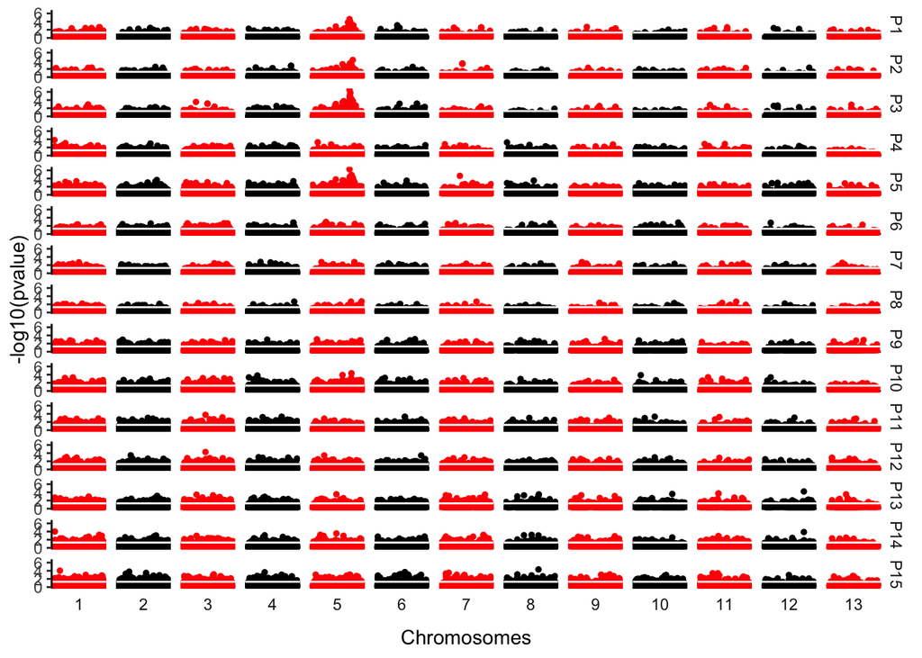

```r
p1 <- ggplot(my.df %>% filter(scaffold < 14),
             aes(x = position, y=-log10(codominant))) +
  #geom_histogram(binwidth = 1, aes(fill=colour, col=colour)) +
  geom_hline(yintercept=0) +
  geom_point(aes(fill=colour, col=colour), size = 1) +
  facet_grid(Pop~scaffold, scales = "free_x", switch = "x") +
  geom_hline(yintercept=(-log10(0.05)),colour="white") +
  theme_classic() +
  scale_fill_manual(values = c("black","red")) +
  scale_color_manual(values = c("black","red")) +
  theme(axis.text.x = element_blank(),
        axis.ticks.x = element_blank(),
        axis.line.x = element_blank(),
        strip.background = element_blank(),
        legend.position = "none") +
  labs(y = "-log10(pvalue)", x = "Chromosomes")

p1
```

This first graph shows the original p-values before correction. Now let's plot it after FDR correction.

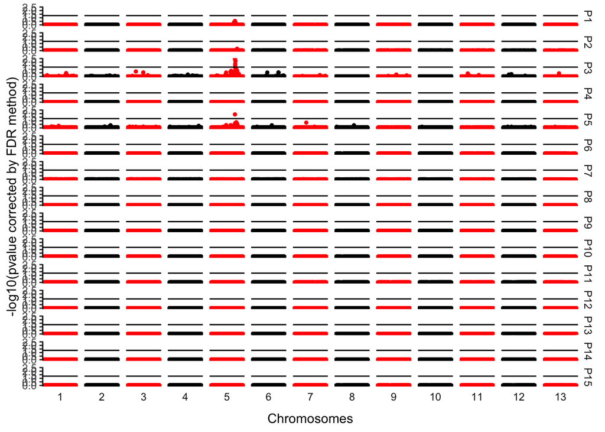

```r
p2 <- ggplot(my.df %>% filter(scaffold < 14),
             aes(x = position, y=-log10(fdr))) +
  #geom_histogram(binwidth = 1, aes(fill=colour, col=colour)) +
  geom_hline(yintercept=0) +
  geom_point(aes(fill=colour, col=colour), size = 1) +
  facet_grid(Pop~scaffold, scales = "free_x", switch = "x") +
  geom_hline(yintercept=(-log10(0.05)),colour="black") +
  theme_classic() +
  scale_fill_manual(values = c("black","red")) +
  scale_color_manual(values = c("black","red")) +
  theme(axis.text.x = element_blank(),
        axis.ticks.x = element_blank(),
        axis.line.x = element_blank(),
        strip.background = element_blank(),
        legend.position = "none") +
  labs(y = "-log10(pvalue corrected by FDR method)", x = "Chromosomes")

p2
```

Save both plots

```r
ggsave("../7_GWAS/7_5_PAll_pvalueVsChromosomes.png", p1,
       device = "png", dpi = 300, width = 8, height = 12)
ggsave("../7_GWAS/7_5_PAll_pvalueFDRVsChromosomes.png", p2,
       device = "png", dpi = 300, width = 8, height = 12)
```